# Subject 1001B: Demographics

Shuying Yu

7/13/2022

# Introduction

Data of the *cleaned* sample of Healthy Aging Participants, meaning that these are participants that we have decided to include based on complete fMRI scans, no major health problems from demographic survey, and from previous team discussions of who to exclude as we wrapped up recruitment for the study.

Subjects ranged from 301-437, scanned over the course of March 1, 2017 to February 10, 2022.

Figures will only include basic demographic and neurpsychiatric batteries. Given little overlap between the type of neuropsychiatric assessments between the HAS sample and subject 1001B, more data pulled from the Reproductive Heath Questionnaire from the demographic survey will be included in this report.

# Basic Demographics

Age (years), BMI, highest completed level of education (years), and verbal IQ

**Age:** Ranges from 43-60 years old

**BMI:** Healthy adult BMI levels are about 19-25

**Education:**

- Some College or Associate’s = 14 years
- Bachelor’s = 16 years
- Master’s = 18 years
- Doctoral = 20 years

## Reproductive Status

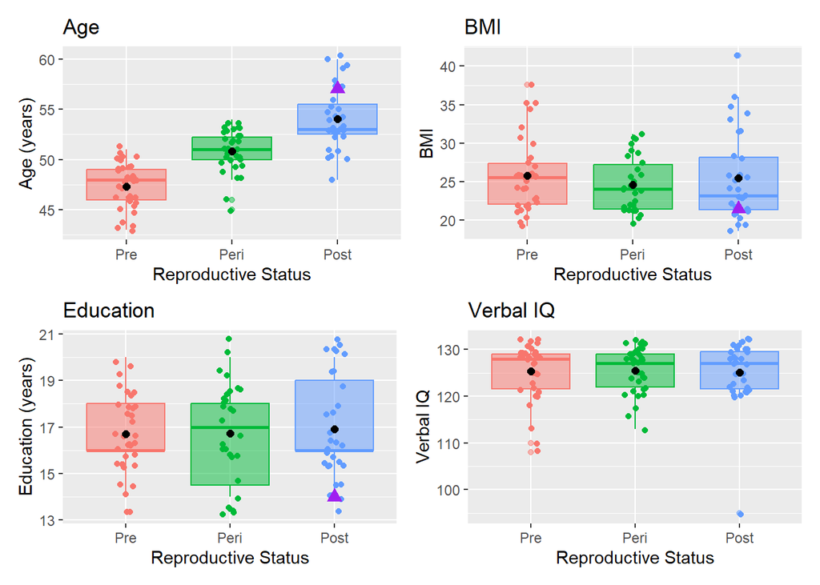

Suject 1001B:

Subject 1001B did not do AMNART for Verbal IQ.

## Sex

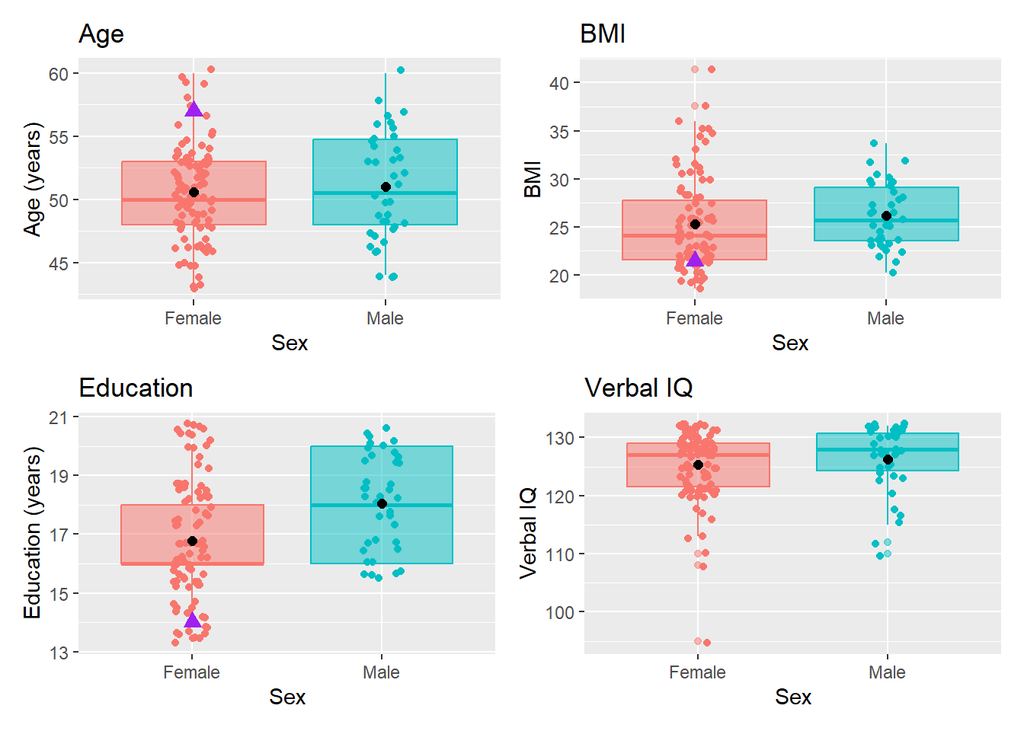

## Total

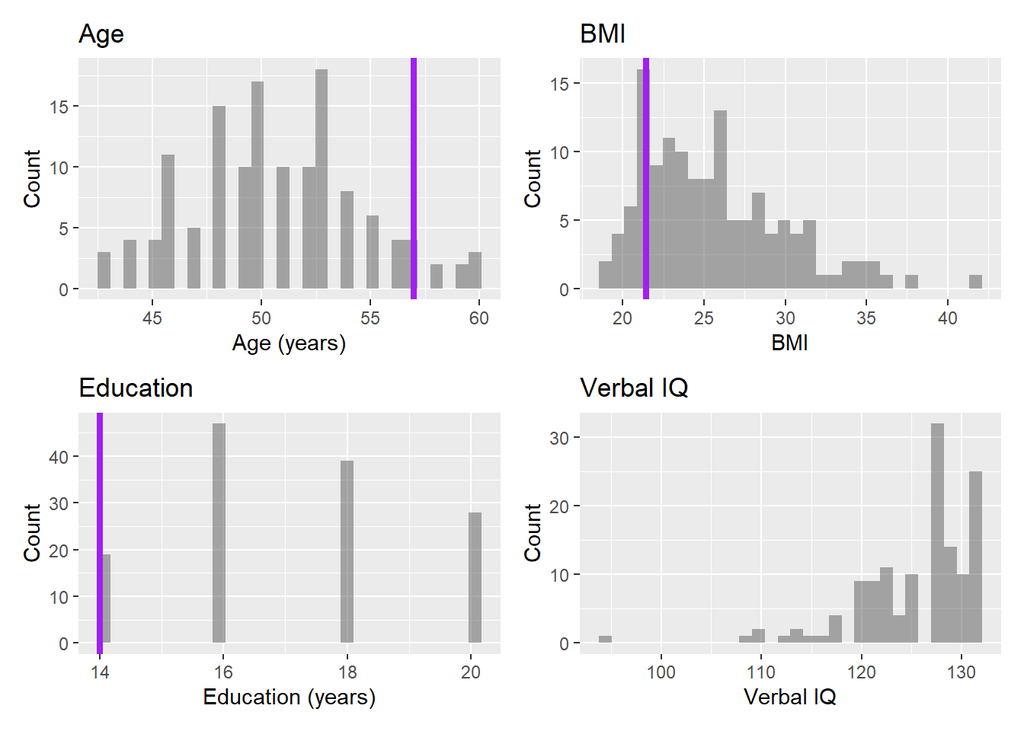

# Reproductive Health Characteristics

Women only. Includes only age at menarche (years) and time since last menstrual cycle (years).

Age characteristics of clean HAS sample of women, by reproductive stages.

| Reproductive Status | Straw-10 Stages | Count | Mean Age (years) | Standard Deviation of Age (years) | Minimum Age (years) | Maximum Age (years) |
| --- | --- | --- | --- | --- | --- | --- |
| Pre | -3a | 3 | 46.33 | 3.51 | 43 | 50 |
| Pre | -3b | 1 | 46.00 | NA | 46 | 46 |
| Peri | -1 | 1 | 50.00 | NA | 50 | 50 |
| Peri | -2 | 3 | 50.67 | 2.31 | 48 | 52 |
| Post | 1b | 2 | 51.50 | 0.71 | 51 | 52 |
| Post | 1c | 2 | 52.00 | 5.66 | 48 | 56 |
| Post | 2 | 1 | 52.00 | NA | 52 | 52 |

## Menarche and Menopause

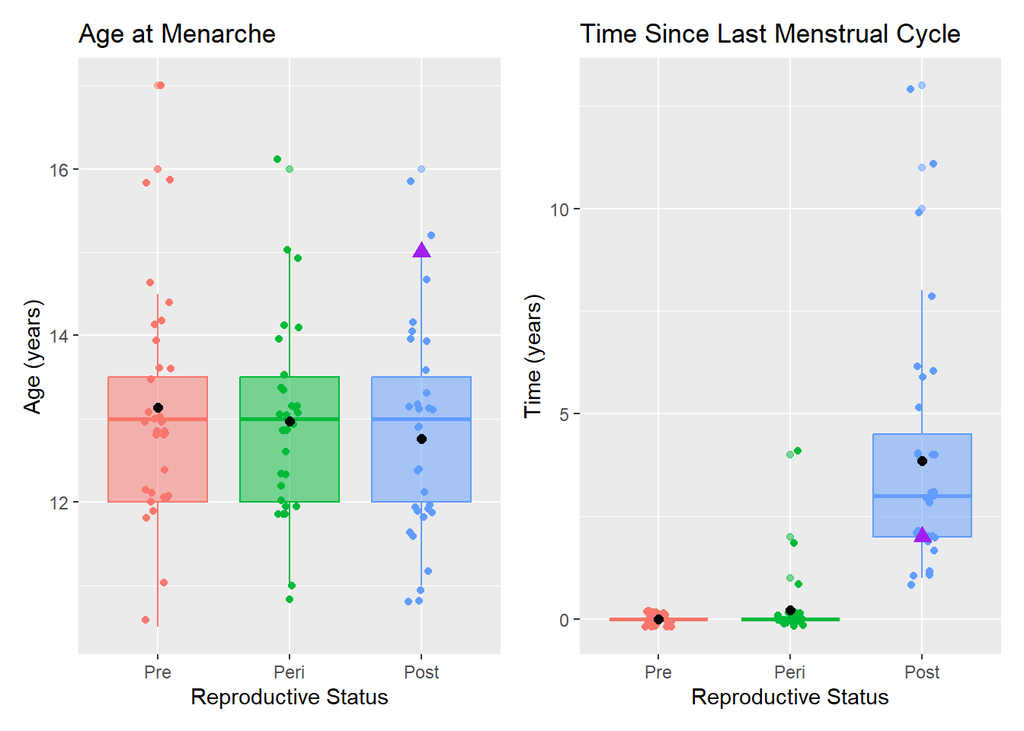

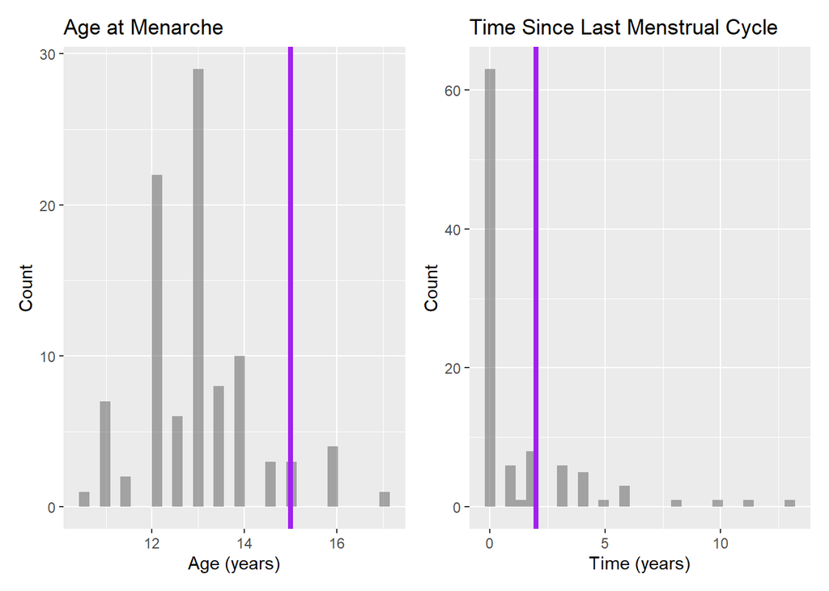

Subject 1001B:

- Age at menarche = 15 years old
- Time since last menstrual cycle = 2 years

## Menopause Symptoms

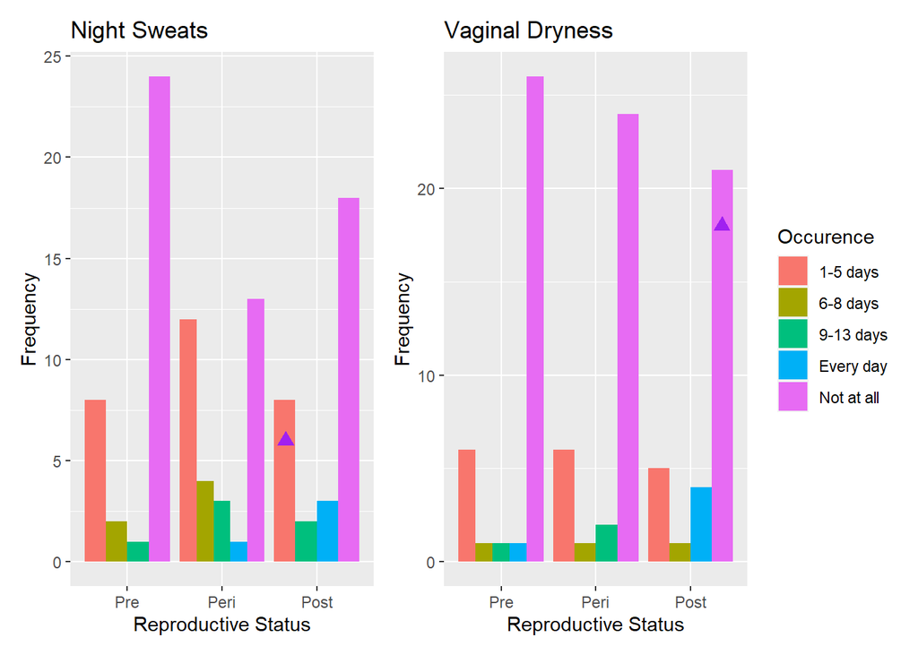

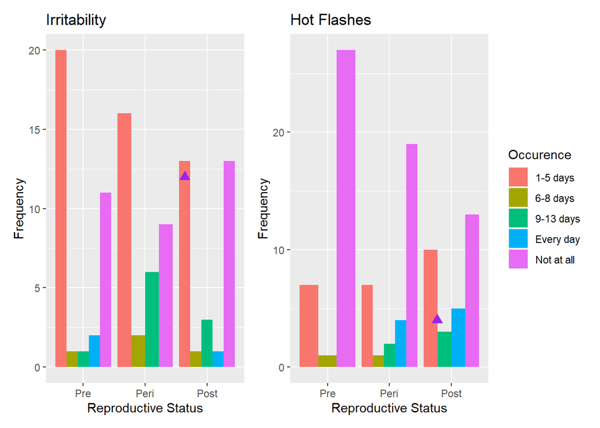

# Neuropsychiatric Assessments

## Edinburgh Handedness

Measures handedness (most are right handed)

- Score of -1.0 = Pure Left Hander
- Score of -0.5 = Mixed Left Hander
- Score of 0.0 = Neutral
- Score of +0.5 = Mixed Right Hander
- Score of +1.0 = Pure Right Hander

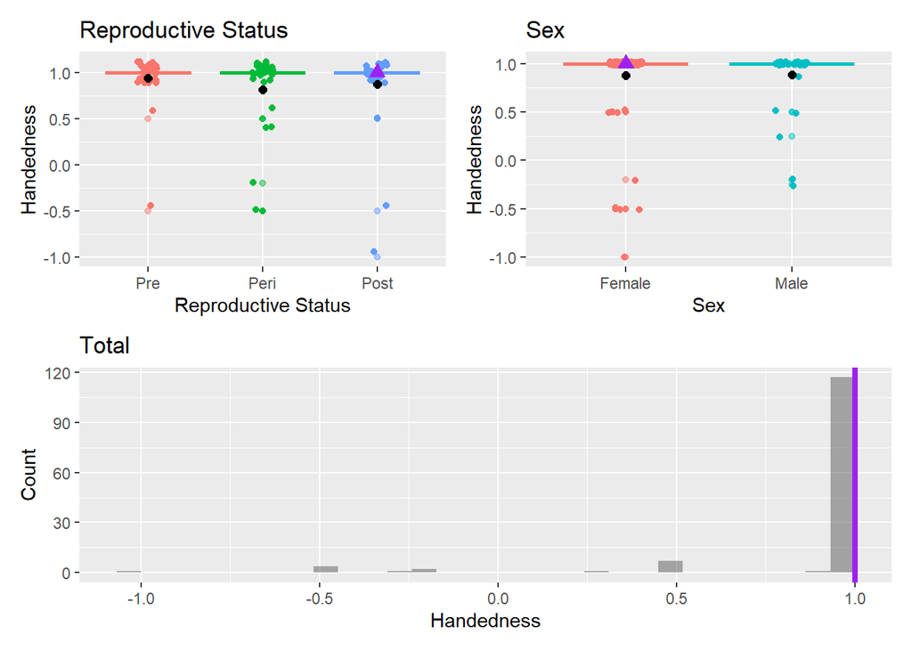

Subject 1001B: score of 1.0 (pure right hander)

## Geriatric Depression

Measures participant depression

- Scores ranging 0-5 are considered normal
- Scores that are 5+ suggest depression

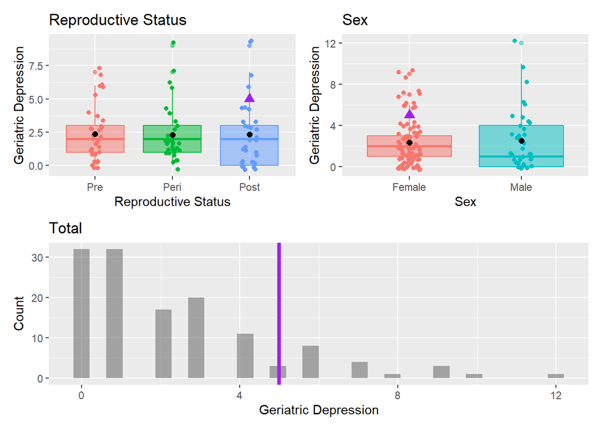

Subject 1001B: score of 5

Scale was developed by Sheikh & Yesavage, 1986.

## PSQI

Pittsburgh Sleep Quality Index. Measures quality of sleep by taking into account 7 components: habitual sleep efficiency, subjective sleep quality, sleep duration, sleep latency, use of sleep medications, sleep disturbances, and daytime dysfunction.

Each component is given a score from 0-3, with 0 meaning no difficulty and 3 meaning having severe difficulty.

The PSQI score thus ranges from 0-21:

- Scores of 0 = No difficulty sleeping
- Score of 21 = Severe difficulties in all components/areas

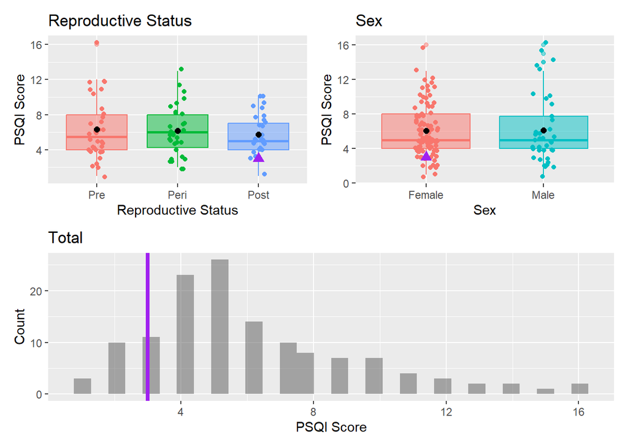

Subject 1001b: score of 3

## STAI

State-Trait Inventory for Adults (STAI) measures participant’s anxiety

**STATE:** current level of anxiety

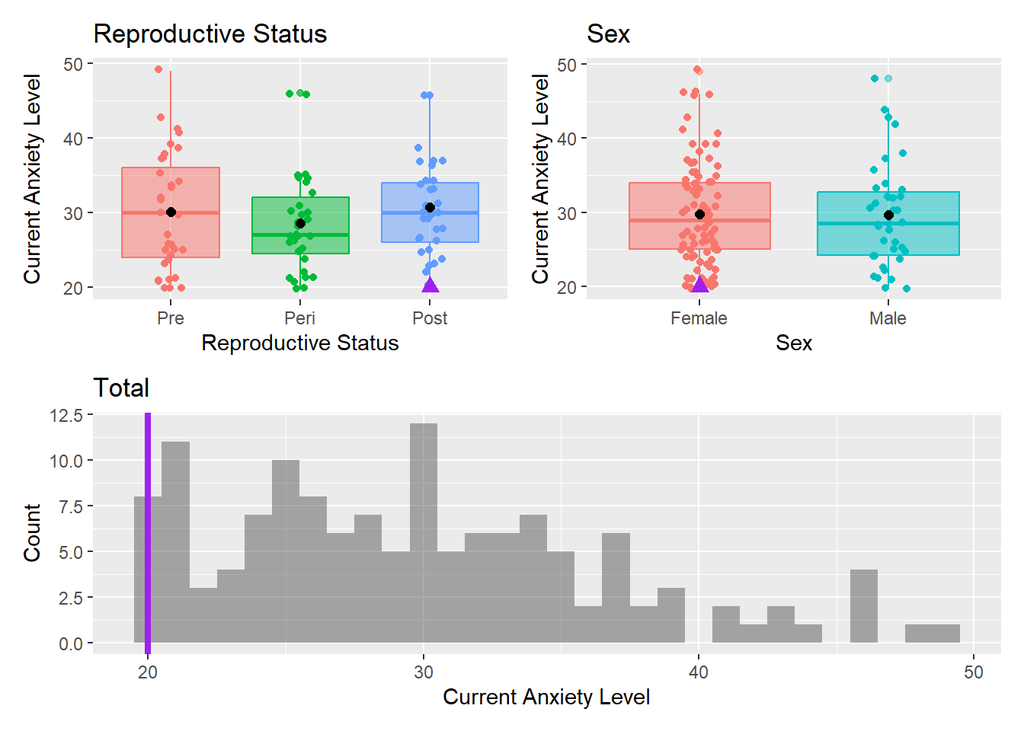

Subject 1001B: score of 20 (for state only)

# Face Name Memory

## Name Learning and Retrieval

Name Learning & Retrieving Composite of:

- Initial recall of names (1st and 2nd rounds)
- Cued recall of names after 2 trials

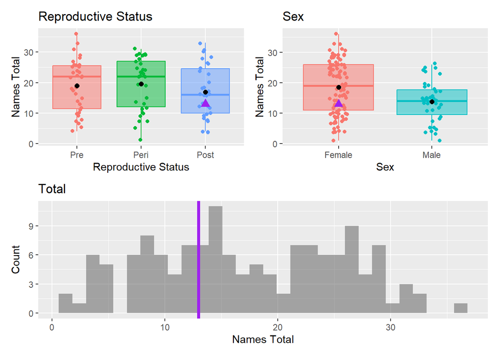

Subject 1001B: score of 13

## Occupation Learning and Retrieval

Occupation Learning & Retrieving Composite

- Initial recall of occupations (1st and 2nd rounds)
- Cued recall of occupations after 2 trials

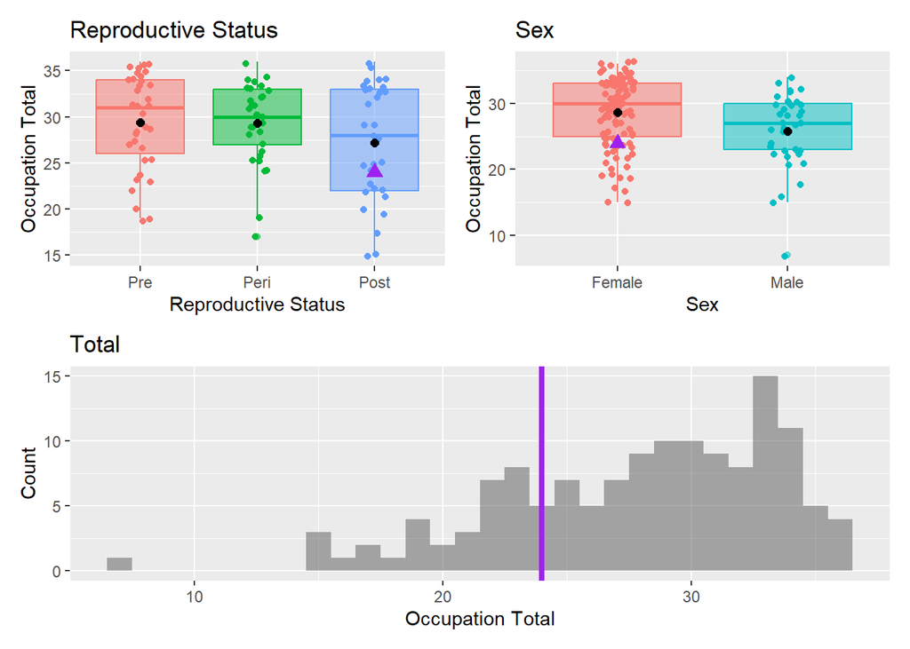

Subject 1001B: score of 24

## Composite Name and Occupation

Composite of Name and Occupation Learning and Recall (Total)

Sum of FNAME-NT and FNAME OT

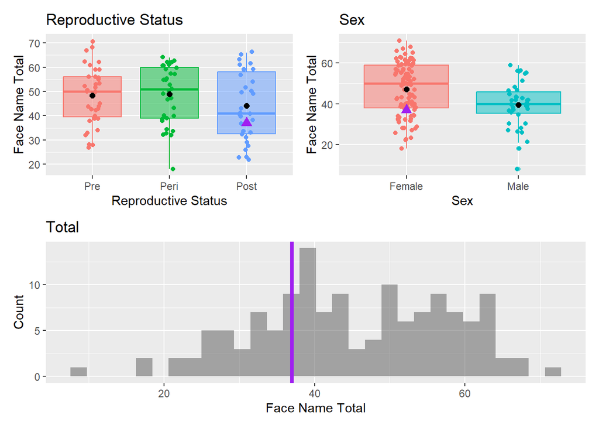

Subject 1001B: score of 37